# America’s Rural Veterans: Where are they and what health challenges do they face?

## Introduction

*Twenty million veterans live in the United States. They live in every state and in nearly every county across the nation. About 5 million veterans lived in areas designated as rural by the U.S. Census Bureau during the 2011–2015 period. Understanding who rural veterans are and what sets them apart from other veterans, as well as from their rural neighbors, provides the necessary perspective for rural communities, government agencies, veterans’ advocates, and other policymakers interested in directing programs and services to this population.*

The U.S. Department of Veterans Affairs (VA) has identified veterans living in rural areas as a population of interest. To help address concerns of veterans’ access to care, Congress established the Office of Rural Health within the VA in 2007. One challenge in these efforts is that most of the data available to the VA come only from rural veterans enrolled in their healthcare system, and not all veterans are enrolled. However, to anticipate demand for care, as well as to understand what types of services may be requested or utilized, requires data on all rural veterans.

[This brief](https://www.census.gov/content/dam/Census/library/publications/2017/acs/acs-36.pdf) aims to answer the question “Who are rural veterans?” by considering the demographic, social, and economic characteristics of rural veterans compared with both urban veterans as well as with rural nonveterans. It also examines rural veterans by the level of rurality of their county of residence to understand some of the impact of geography on their characteristics. The data used in this report are primarily from 2011–2015 American Community Survey (ACS), 5-year estimates. This report presents statistics about veterans and, where applicable, nonveterans 18 years and older living in rural and urban areas of the United States.

REPORT NUMBER ACS-36  
KELLY ANN HOLDER

To read the full brief click [here](https://www.census.gov/content/dam/Census/library/publications/2017/acs/acs-36.pdf).

## Shiny App

To view the shiny app associated with this repository, click [here](https://li11ianc.shinyapps.io/rural_veterans/).

This app allows viewers to explore characteristics of rural and urban veterans in the United States, including poverty level, employment, health insurance, and service-connected disability.

Viewers can opt to peruse data at the federal level.

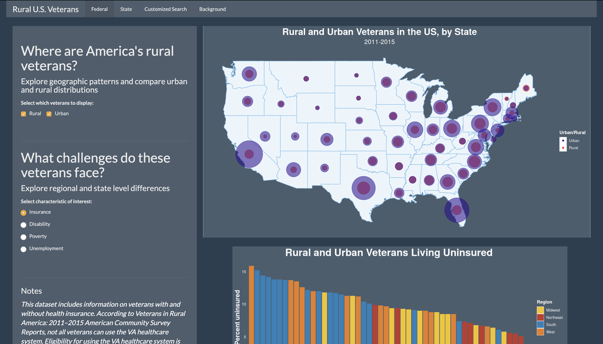

They can also choose to view key statistics and comparisons of disability, insurance, and poverty for each of the 50 states- this exploration allows viewers to contrast the percentage of veterans in each state who are rural residents with the percentages of disabled, uninsured, and impoverished veterans who are rural residents.

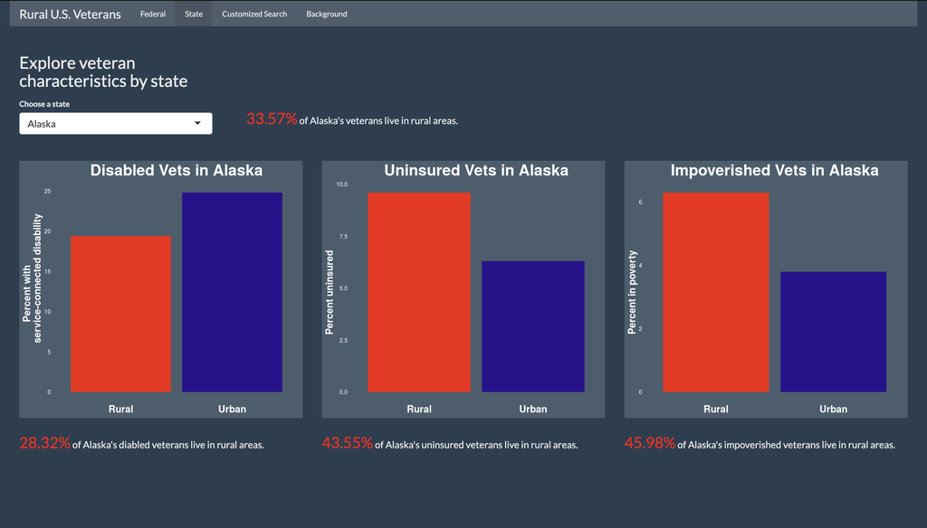

A final option allows viewers to search for states which exceed certain percentages of veterans being disabled, uninsured, unemployed, or impoverished. For example, you could search for states in which over 20% of rural veterans are living with a service-connected disability.

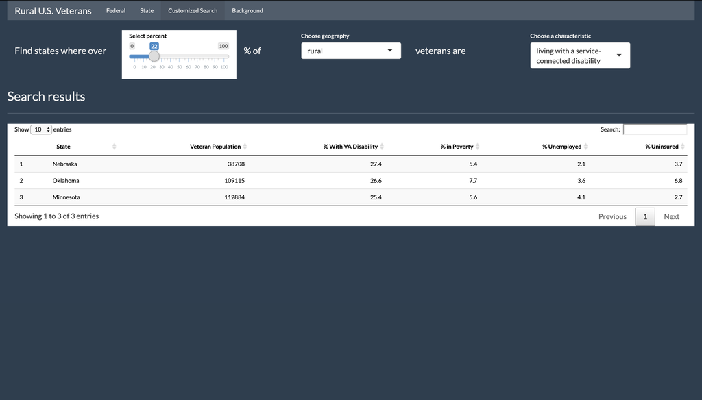

Finally, the app’s background section also provides context for why rural/urban veteran health analysis is important, and particularly at the state level.

## References

### Code

https://stackoverflow.com/questions/48219732/pass-a-string-as-variable-name-in-dplyrfilter

http://www.sthda.com/english/wiki/reordering-data-frame-columns-in-r#reorder-column-by-name

https://stackoverflow.com/questions/24142942/how-to-remove-duplicated-column-names-in-r

https://stackoverflow.com/questions/31549782/shiny-how-to-change-a-background-colour-of-a-column

https://shiny.rstudio.com/articles/css.html

### Data

- Bureau, U. (2018). Veterans in Rural America: 2011–2015. The United States Census Bureau. Retrieved 20 March 2020, from https://www.census.gov/library/publications/2017/acs/acs-36.html